# Màster Universitari en Ciència de Dades

# M2.951 - Tipologia i cicle de vida de les dades

Autors: Francisco J. Bastida López (fbastidal@uoc.edu) / Ivan Benaiges Trenchs (ibenaiges@uoc.edu)

Juny 2023

# Descripció de la Pràctica a realitzar

L’objectiu d’aquesta activitat serà el tractament d’un dataset, que pot ser el creat a la pràctica 1 o bé qualsevol dataset lliure disponible a Kaggle (https://www.kaggle.com).

Un exemple de dataset amb el qual podeu treballar és el “Heart Attack Analysis & Prediction dataset” (https://www.kaggle.com/datasets/rashikrahmanpritom/heart-attack-analysis-prediction-dataset).

Important: si escolliu un dataset diferent al proposat és important que aquest contingui una àmplia varietat de dades numèriques i categòriques per poder fer una anàlisi més rica i poder respondre a les diferents preguntes plantejades a l’enunciat de la pràctica. Seguint les principals etapes d’un projecte analític, les diferents tasques a realitzar (i justificar) són les següents:

1. **Descripció del dataset.** Perquè és important i quina pregunta/problema pretén respondre?
2. **Integració i selecció** de les dades d’interès a analitzar. Pot ser el resultat d’addicionar diferents datasets o una subselecció útil de les dades originals, en base a l’objectiu que es vulgui aconseguir.
3. **Neteja de les dades.** 3.1. Les dades contenen zeros o elements buits? Gestiona cadascun d’aquests casos. 3.2. Identifica i gestiona els valors extrems.
4. **Anàlisi de les dades.** 4.1. Selecció dels grups de dades que es volen analitzar/comparar (p. e., si es volen comparar grups de dades, quins són aquests grups i quins tipus d’anàlisi s’aplicaran?). 4.2. Comprovació de la normalitat i homogeneïtat de la variància. 4.3. Aplicació de proves estadístiques per comparar els grups de dades. En funció de les dades i de l’objectiu de l’estudi, aplicar proves de contrast d’hipòtesis, correlacions, regressions, etc. Aplicar almenys tres mètodes d’anàlisi diferents.
5. **Representació dels resultats** a partir de taules i gràfiques. Aquest apartat es pot respondre al llarg de la pràctica, sense la necessitat de concentrar totes les representacions en aquest punt de la pràctica.
6. **Resolució del problema.** A partir dels resultats obtinguts, quines són les conclusions? Els resultats permeten respondre al problema?
7. **Codi.** Cal adjuntar el codi, preferiblement en R, amb el que s’ha realitzat la neteja, anàlisi i representació de les dades. Si ho preferiu, també podeu treballar en Python.
8. **Vídeo.** Realitzar un breu vídeo explicatiu de la pràctica (màxim 10 minuts) on tots els integrants de l’equip expliquin amb les seves pròpies paraules el desenvolupament de la pràctica, basant-se en les preguntes de l’enunciat per a justificar i explicar el codi desenvolupat. Aquest vídeo s’haurà de lliurar a través d’un enllaç al Google Drive de la UOC (https://drive.google.com/…), juntament amb l’enllaç al repositori Git lliurat.

# 1 Descripció del dataset

Inicialment s’havia pensat aprofitar les dades recopilades durant la primera pràctica, relacionades amb dades de navegació de vaixells. No obstant, després de valorar-ho, no trobavem com poder utilitzar-lo de forma bastant gràfica i que ens permetés realitzar un estudi estadístic com el que es demana a l’enunciat, pel que finalment hem decidit utilitzar el conjunt de dades que es posa com a exemple a l’enunciat, ja que considerem que resulta molt interessant i pot donar més joc al estar relacionat amb temes de salut.

El conjunt de dades seleccionat “[Heart Attack Analysis & Prediction dataset](https://www.kaggle.com/datasets/rashikrahmanpritom/heart-attack-analysis-prediction-dataset)” proporciona informació sobre diferents factors que podrien estar relacionats amb malalties cardiovasculars, més concretament amb predir la probabilitat de patir un atac de cor.

Es tracta d’un conjunt de dades que ens permetrà realitzar un estudi en major profunditat de possibles problemes del cor, molt més centrat en els atacs de cor, al tenir una variable que està directament relacionada amb el resultat que es va obtenir durant l’estudi dels pacients i que ens permeti trobar un model per determinar la probabilitat de patir un atac de cor segons els valors dels diferents factors d’estudi.

Per poder facilitar aquesta anàlisi, el dataset conté el fitxer *heart.csv* amb les següents variables/atributs:

- **age**: edat del pacient
- **sex**: gènere del pacient
  - 0 = femení
  - 1 = masculí
- **cp**: tipus de dolor toràcic que experimenta el pacient
  - 0 = angina típica
  - 1 = angina atípica
  - 2 = dolor no relacionat amb angina
  - 3 = asimptomàtic (sense dolor toràcic)
- **trtbps**: pressió arterial en repòs (mm Hg)
- **chol**: nivell de colesterol (md/dl)
- **fbs**: nivell de sucre en sang en dejú
  - 0 = normal
  - 1 = alt)
- **restecg**: resultat de l’electrocardiograma en repòs
  - 0 = normal
  - 1 = anomalies en l’ona ST-T
  - 2 = hipertrofia ventricular esquerra probable o definitiva segons els criteris d’Estes
- **thalachh**: freqüència cardíaca màxima registrada pel pacient durant les proves realitzades
- **exng**: angina provocada per l’exercici
  - 0 = no
  - 1 = sí
- **oldpeak**: canvis en el segment ST de l’electrocardiograma després de l’exercici físic
- **slp**: patró de canvi en el segment ST de l’electrocardiograma durant una prova d’esforç o situacions d’estrès
  - 0 = pendent plana
  - 1 = pendent ascendent (canvi en el patró elèctric del cor)
  - 2 = pendent descendent (canvi en el patró elèctric del cor)
- **caa**: nombre de vasos sanguinis coronaris que mostren obstrucció o estenosi significativa
  - 0 = sense obstrucció detectada
  - 1 = obstrucció en un dels vasos sanguinis
  - 2 = obstrucció en dos dels vasos sanguinis
  - 3 = obstrucció en tres dels vasos sanguinis
  - 4 = obstrucció en els quatre vasos sanguinis
- **thall**: relacionat amb una malaltia hereditària de la sang anomenada talassèmia
  - 1 = no s’ha detectat cap indici
  - 2 = presència d’un defecte fix
  - 3 = presència d’un defecte reversible
- **output**: probabilitat de patir un atac de cor:
  - 0 = sense o poca probabilitat
  - 1 = major probabilitat

Per altra banda, hi ha disponible un segon fitxer, *o2Saturation.csv*, que conté múltiples observacions relacionades amb el nivell de saturació d’oxigen (una única variable). El fitxer conté moltíssimes més observacions (3586 en total) sense cap tipus d’idenfificador que ens permeti poder realitzar una integració de les dades d’ambdós fitxers per tenir un conjunt més complet.

# 2 Integració i selecció de les dades d’interès a analitzar

## 2.1 Càrrega de dades

Abans de començar, és necessari carregar el fitxer en un data frame que ens permeti treballar de forma còmoda amb les dades a través del codi en R:

```r
# El joc de dades està conformat per un fitxer CSV, amb separació per comes i amb una capçalera, pel que carreguem el fitxer utilitzant la següent funció:
dfHeartAttack <- read.csv("../dataset/heart.csv", header=TRUE)
```

Una vegada carregades totes les dades, procedim a un primer anàlisi ràpid a partir del resum estadístic del data frame:

```r
# Mostrem la informació bàsica del data frame per comprovar si s'han de realitzar canvis a simple vista:
str(dfHeartAttack)
```

```
## 'data.frame':    303 obs. of  14 variables:
##  $ age     : int  63 37 41 56 57 57 56 44 52 57 ...
##  $ sex     : int  1 1 0 1 0 1 0 1 1 1 ...
##  $ cp      : int  3 2 1 1 0 0 1 1 2 2 ...
##  $ trtbps  : int  145 130 130 120 120 140 140 120 172 150 ...
##  $ chol    : int  233 250 204 236 354 192 294 263 199 168 ...
##  $ fbs     : int  1 0 0 0 0 0 0 0 1 0 ...
##  $ restecg : int  0 1 0 1 1 1 0 1 1 1 ...
##  $ thalachh: int  150 187 172 178 163 148 153 173 162 174 ...
##  $ exng    : int  0 0 0 0 1 0 0 0 0 0 ...
##  $ oldpeak : num  2.3 3.5 1.4 0.8 0.6 0.4 1.3 0 0.5 1.6 ...
##  $ slp     : int  0 0 2 2 2 1 1 2 2 2 ...
##  $ caa     : int  0 0 0 0 0 0 0 0 0 0 ...
##  $ thall   : int  1 2 2 2 2 1 2 3 3 2 ...
##  $ output  : int  1 1 1 1 1 1 1 1 1 1 ...
```

```r
# Mostrem també un resum estadístic de les variables/atributs que conformen el joc de dades:
summary(dfHeartAttack)
```

```
##       age             sex               cp            trtbps
##  Min.   :29.00   Min.   :0.0000   Min.   :0.000   Min.   : 94.0
##  1st Qu.:47.50   1st Qu.:0.0000   1st Qu.:0.000   1st Qu.:120.0
##  Median :55.00   Median :1.0000   Median :1.000   Median :130.0
##  Mean   :54.37   Mean   :0.6832   Mean   :0.967   Mean   :131.6
##  3rd Qu.:61.00   3rd Qu.:1.0000   3rd Qu.:2.000   3rd Qu.:140.0
##  Max.   :77.00   Max.   :1.0000   Max.   :3.000   Max.   :200.0
##       chol            fbs            restecg          thalachh
##  Min.   :126.0   Min.   :0.0000   Min.   :0.0000   Min.   : 71.0
##  1st Qu.:211.0   1st Qu.:0.0000   1st Qu.:0.0000   1st Qu.:133.5
##  Median :240.0   Median :0.0000   Median :1.0000   Median :153.0
##  Mean   :246.3   Mean   :0.1485   Mean   :0.5281   Mean   :149.6
##  3rd Qu.:274.5   3rd Qu.:0.0000   3rd Qu.:1.0000   3rd Qu.:166.0
##  Max.   :564.0   Max.   :1.0000   Max.   :2.0000   Max.   :202.0
##       exng           oldpeak          slp             caa
##  Min.   :0.0000   Min.   :0.00   Min.   :0.000   Min.   :0.0000
##  1st Qu.:0.0000   1st Qu.:0.00   1st Qu.:1.000   1st Qu.:0.0000
##  Median :0.0000   Median :0.80   Median :1.000   Median :0.0000
##  Mean   :0.3267   Mean   :1.04   Mean   :1.399   Mean   :0.7294
##  3rd Qu.:1.0000   3rd Qu.:1.60   3rd Qu.:2.000   3rd Qu.:1.0000
##  Max.   :1.0000   Max.   :6.20   Max.   :2.000   Max.   :4.0000
##      thall           output
##  Min.   :0.000   Min.   :0.0000
##  1st Qu.:2.000   1st Qu.:0.0000
##  Median :2.000   Median :1.0000
##  Mean   :2.314   Mean   :0.5446
##  3rd Qu.:3.000   3rd Qu.:1.0000
##  Max.   :3.000   Max.   :1.0000
```

Veiem que tenim un joc de dades compost per un total de 303 observacions i 14 variables.

## 2.2 Anàlisi exploratori

Realitzem un primer anàlisi exploratori que ens permeti entendre millor el conjunt de dades:

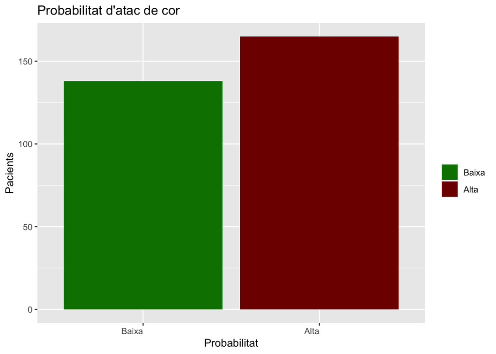

```r
# Visualitzem la quantitat d'observacions que s'han identificat amb una probabilitat més alta i més baixa que es van identificar en  referència als atacs de cor:
ggplot(dfHeartAttack,aes(factor(output, levels = c(0, 1), labels = c("Baixa", "Alta")), fill=factor(output, levels = c(0, 1), labels = c("Baixa", "Alta")))) +
    geom_bar() +labs(x="Probabilitat", y="Pacients") +
        guides(fill=guide_legend(title="")) +
        scale_fill_manual(values=c("#008000","#800000")) +
        ggtitle("Probabilitat d'atac de cor") +
    theme(axis.text.x = element_text(hjust = 1))
```

```r
# Calculem la proporció per poder tenir una idea de com es reparteixen les observacions:
table(dfHeartAttack$output)/length(dfHeartAttack$output)
```

```
##
##         0         1
## 0.4554455 0.5445545
```

Veiem que les dades estan molt repartides entre els pacients que tenen una probabilitat major i menor de patir un atac de cor segons els factors registrats.

Vegem la probabilitat de patir un atac de cor en base a les diferents variables:

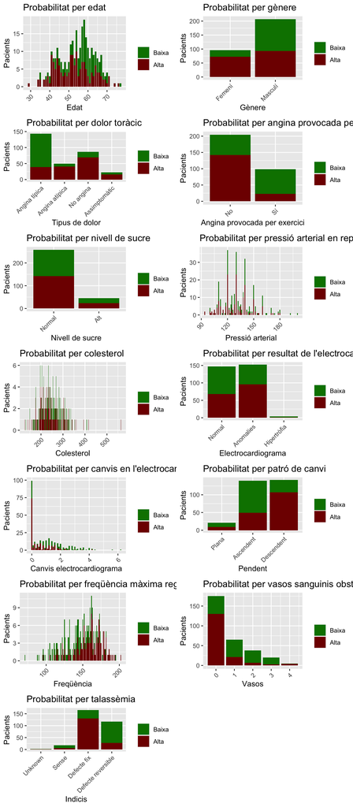

```r
plotbyAge <- ggplot(dfHeartAttack,aes(age, fill=factor(output, levels = c(0, 1), labels = c("Baixa", "Alta")))) +
                    geom_bar() +labs(x="Edat", y="Pacients") +
                    guides(fill=guide_legend(title="")) +
                  scale_fill_manual(values=c("#008000","#800000")) +
                    ggtitle("Probabilitat per edat") +
          theme(axis.text.x = element_text(angle = 45, hjust = 1))

plotbySex <- ggplot(dfHeartAttack,aes(factor(sex, levels = c(0, 1), labels = c("Femení", "Masculí")), fill=factor(output, levels = c(0, 1), labels = c("Baixa", "Alta")))) +
                    geom_bar() +labs(x="Gènere", y="Pacients") +
                    guides(fill=guide_legend(title="")) +
                  scale_fill_manual(values=c("#008000","#800000")) +
                    ggtitle("Probabilitat per gènere") +
          theme(axis.text.x = element_text(angle = 45, hjust = 1))

plotbyCP <- ggplot(dfHeartAttack,aes(factor(cp, levels = c(0, 1, 2, 3), labels = c("Angina típica", "Angina atípica", "No angina", "Assimptomàtic")), fill=factor(output, levels = c(0, 1), labels = c("Baixa", "Alta")))) +
                    geom_bar() +labs(x="Tipus de dolor", y="Pacients") +
                    guides(fill=guide_legend(title="")) +
                  scale_fill_manual(values=c("#008000","#800000")) +
                    ggtitle("Probabilitat per dolor toràcic") +
          theme(axis.text.x = element_text(angle = 45, hjust = 1))

plotbyExng <- ggplot(dfHeartAttack,aes(factor(exng, levels = c(0, 1), labels = c("No", "Sí")), fill=factor(output, levels = c(0, 1), labels = c("Baixa", "Alta")))) +
                    geom_bar() +labs(x="Angina provocada per exercici", y="Pacients") +
                    guides(fill=guide_legend(title="")) +
                  scale_fill_manual(values=c("#008000","#800000")) +
                    ggtitle("Probabilitat per angina provocada per exercici") +
          theme(axis.text.x = element_text(angle = 45, hjust = 1))

plotbyFBS <- ggplot(dfHeartAttack,aes(factor(fbs, levels = c(0, 1), labels = c("Normal", "Alt")), fill=factor(output, levels = c(0, 1), labels = c("Baixa", "Alta")))) +
                    geom_bar() +labs(x="Nivell de sucre", y="Pacients") +
                    guides(fill=guide_legend(title="")) +
                  scale_fill_manual(values=c("#008000","#800000")) +
                    ggtitle("Probabilitat per nivell de sucre") +
          theme(axis.text.x = element_text(angle = 45, hjust = 1))

plotbyTRTBPS <- ggplot(dfHeartAttack,aes(trtbps, fill=factor(output, levels = c(0, 1), labels = c("Baixa", "Alta")))) +
                    geom_bar() +labs(x="Pressió arterial", y="Pacients") +
                    guides(fill=guide_legend(title="")) +
                  scale_fill_manual(values=c("#008000","#800000")) +
                    ggtitle("Probabilitat per pressió arterial en repòs") +
          theme(axis.text.x = element_text(angle = 45, hjust = 1))

plotbyChol <- ggplot(dfHeartAttack,aes(chol, fill=factor(output, levels = c(0, 1), labels = c("Baixa", "Alta")))) +
                    geom_bar() +labs(x="Colesterol", y="Pacients") +
                    guides(fill=guide_legend(title="")) +
                  scale_fill_manual(values=c("#008000","#800000")) +
                    ggtitle("Probabilitat per colesterol") +
          theme(axis.text.x = element_text(angle = 45, hjust = 1))

plotbyRestecg <- ggplot(dfHeartAttack,aes(factor(restecg, levels = c(0, 1, 2), labels = c("Normal", "Anomalies", "Hipertròfia")), fill=factor(output, levels = c(0, 1), labels = c("Baixa", "Alta")))) +
                    geom_bar() +labs(x="Electrocardiograma", y="Pacients") +
                    guides(fill=guide_legend(title="")) +
                  scale_fill_manual(values=c("#008000","#800000")) +
                    ggtitle("Probabilitat per resultat de l'electrocardiograma") +
          theme(axis.text.x = element_text(angle = 45, hjust = 1))

plotbyOldpeak <- ggplot(dfHeartAttack,aes(oldpeak, fill=factor(output, levels = c(0, 1), labels = c("Baixa", "Alta")))) +
                    geom_bar() +labs(x="Canvis electrocardiograma", y="Pacients") +
                    guides(fill=guide_legend(title="")) +
                  scale_fill_manual(values=c("#008000","#800000")) +
                    ggtitle("Probabilitat per canvis en l'electrocardiograma") +
          theme(axis.text.x = element_text(angle = 45, hjust = 1))

plotbySLP <- ggplot(dfHeartAttack,aes(factor(slp, levels = c(0, 1, 2), labels = c("Plana", "Ascendent", "Descendent")), fill=factor(output, levels = c(0, 1), labels = c("Baixa", "Alta")))) +
                    geom_bar() +labs(x="Pendent", y="Pacients") +
                    guides(fill=guide_legend(title="")) +
                  scale_fill_manual(values=c("#008000","#800000")) +
                    ggtitle("Probabilitat per patró de canvi") +
          theme(axis.text.x = element_text(angle = 45, hjust = 1))

plotbyThalachh <- ggplot(dfHeartAttack,aes(thalachh, fill=factor(output, levels = c(0, 1), labels = c("Baixa", "Alta")))) +
                    geom_bar() +labs(x="Freqüència", y="Pacients") +
                    guides(fill=guide_legend(title="")) +
                  scale_fill_manual(values=c("#008000","#800000")) +
                    ggtitle("Probabilitat per freqüència màxima registrada") +
          theme(axis.text.x = element_text(angle = 45, hjust = 1))

plotbyCAA <- ggplot(dfHeartAttack,aes(caa, fill=factor(output, levels = c(0, 1), labels = c("Baixa", "Alta")))) +
                    geom_bar() +labs(x="Vasos", y="Pacients") +
                    guides(fill=guide_legend(title="")) +
                  scale_fill_manual(values=c("#008000","#800000")) +
                    ggtitle("Probabilitat per vasos sanguinis obstruïts") +
          theme(axis.text.x = element_text(angle = 45, hjust = 1))

plotbyThall <- ggplot(dfHeartAttack,aes(factor(thall, levels = c(0, 1, 2, 3), labels = c("Unknown", "Sense", "Defecte fix", "Defecte reversible")), fill=factor(output, levels = c(0, 1), labels = c("Baixa", "Alta")))) +
                    geom_bar() +labs(x="Indicis", y="Pacients") +
                    guides(fill=guide_legend(title="")) +
                  scale_fill_manual(values=c("#008000","#800000")) +
                    ggtitle("Probabilitat per talassèmia") +
          theme(axis.text.x = element_text(angle = 45, hjust = 1))

grid.newpage()
grid.arrange(plotbyAge, plotbySex, plotbyCP, plotbyExng, plotbyFBS, plotbyTRTBPS, plotbyChol, plotbyRestecg, plotbyOldpeak, plotbySLP, plotbyThalachh, plotbyCAA, plotbyThall, ncol=2)
```

Finalment, creem un gràfic on es mostrin les possibles relacions existentes entre les variables per veure, de forma ràpida, si podem veure algunes correlacions de forma directa:

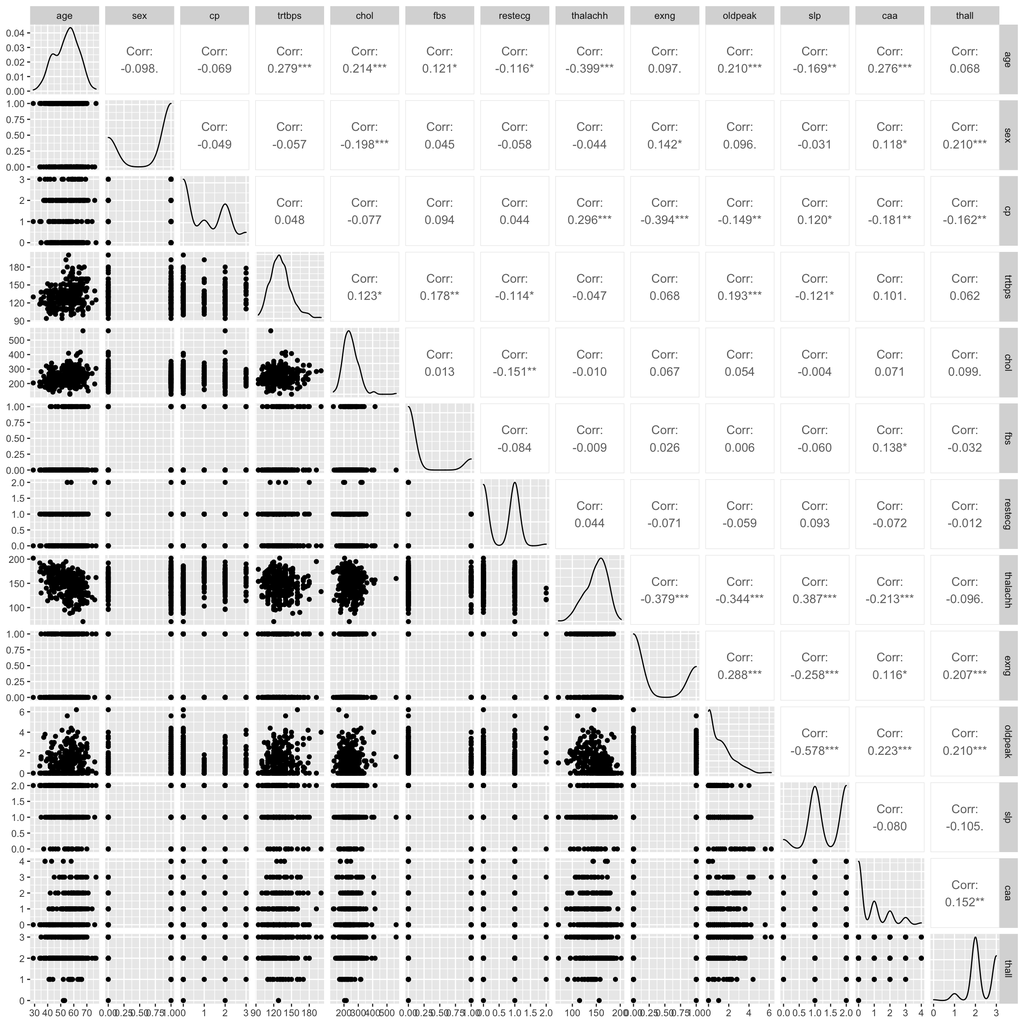

```r
# Generem un gràfic que compara parells de variables entre elles, el que ens permet
ggpairs(data = dfHeartAttack, columns = 1:13)
```

Observant els diversos factors que es troben dins el conjunt de dades i tots els gràfics creats, sembla que la variància entre els diferents valors, així com la, a priori, poca correlació entre les variables i la seva relació amb la probabilitat de patir un atac de cor podria ser interessant mantenir tots els atributs que tenim per poder utilitzar-los durant la resta de l’anàlisi.

# 3 Neteja de les dades

## 3.1 Valors nul·ls

Comprobem si existeixen valors nul·ls en les dades, tot i que, aparentment, al revisar els resultats del resum estadístic anterior sembla que no existeixi cap valor d’aquest tipus:

```r
# Revisem el total de valors NA i blancs que hi ha a cada variable:
colSums(is.na(dfHeartAttack))
```

```
##      age      sex       cp   trtbps     chol      fbs  restecg thalachh
##        0        0        0        0        0        0        0        0
##     exng  oldpeak      slp      caa    thall   output
##        0        0        0        0        0        0
```

```r
colSums(dfHeartAttack == "")
```

```
##      age      sex       cp   trtbps     chol      fbs  restecg thalachh
##        0        0        0        0        0        0        0        0
##     exng  oldpeak      slp      caa    thall   output
##        0        0        0        0        0        0
```

Es confirma que no existeixen valors d’aquest tipus en el conjunt de dades, pel que no serà necessari realitzar cap acció al respecte. En cas de tenir valors d’aquest tipus hauriem de pensar si treure’ls o bé realitzar una aproximació del possible valor a partir de la resta de valors de la variable en qüestió.

## 3.2 Valors atípics

En aquest cas, utilitzarem els diagrames de caixa per poder veure ràpidament si existeix algun valor atípic o outlier en el joc de dades, revisant totes les variables numèriques, no les categòriques:

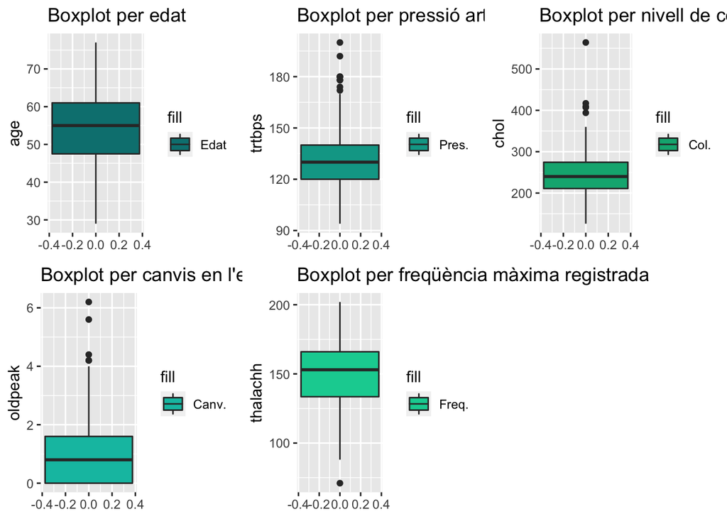

```r
# Calculem els diferents gràfics de caixa:
bpAge <- ggplot(data = dfHeartAttack) +
  geom_boxplot(aes(y = age, fill = "Edat")) +
  scale_fill_manual(values = "#008080") +
  ggtitle("Boxplot per edat")

bpTRTBPS <- ggplot(data = dfHeartAttack) +
  geom_boxplot(aes(y = trtbps, fill = "Pres.")) +
  scale_fill_manual(values = "#00A595") +
  ggtitle("Boxplot per pressió arterial en repòs")

bpChol <- ggplot(data = dfHeartAttack) +
  geom_boxplot(aes(y = chol, fill = "Col.")) +
  scale_fill_manual(values = "#00B080") +
  ggtitle("Boxplot per nivell de colesterol")

bpOldpeak <- ggplot(data = dfHeartAttack) +
  geom_boxplot(aes(y = oldpeak, fill = "Canv.")) +
  scale_fill_manual(values = "#00C0B0") +
  ggtitle("Boxplot per canvis en l'electrocardiograma")

bpThalachh <- ggplot(data = dfHeartAttack) +
  geom_boxplot(aes(y = thalachh, fill = "Freq.")) +
  scale_fill_manual(values = "#00D0A0") +
  ggtitle("Boxplot per freqüència màxima registrada")

# Mostrem els diferents gràfics de forma agrupada:
grid.newpage()
grid.arrange(bpAge, bpTRTBPS, bpChol, bpOldpeak, bpThalachh, ncol=3)
```

- Pressió arterial per sobre de 170: tot i que estigui per sobre del normal, és un valor possible i, per tant, els mantindrem dintre del joc de dades.
- Colesterol per sobre de 400: novament ens trobem davant de valors extrems, però que es troben dins d’un rang possible, pel que mantindrem aquestes observacions dins el joc de dades a analitzar.
- Canvis en l’electrocardiograma per sobre de 4: tot i que està fora dels valors més comuns, no està tant distanciat com per considerar treure’ls de l’anàlisi.
- Freqüència màxima registrada per sota de 100: tot i que existeixi un valor més baix, aquest és un valor possible i, per tant, el mantindrem dins el joc de dades.

En resum, no s’han trobat valors anòmals que puguin considerar-se fora dels valors possibles, tot i que sí hi ha alguns valors extrems degut a les condicions físiques i/o de salut dels diferents pacients.

## 3.3 Normalització

La normalització de les dades ens permet obtenir valors en escales que permetin comparar la magnitud de forma similar entre els diferents rangs de valors que tenen les variables. Tot i que podriem portar a terme aquest procés, no es considera útil en el nostre cas, ja que no ens permetria entendre de forma ràpida els resultats dels anàlisis per exemple si es busca els resultats per algú d’una edat específica, sent necessari un càlcul previ per aplicar la mateixa escala.

Per tant, s’ha decidit no normalitzar les observacions del joc de dades, tot i que seria possible si es volgués millorar una mica el rendiment al utilitzar un conjunt de dades que fos molt més gran que el que ens ocupa.

## 3.4 Discretització

Afegirem alguns nous valors de forma que s’agrupin les observacions numèriques i ens permetin tenir altres variables categòriques que puguin resultar útils durant l’anàlisi:

```r
# Carreguem la llibreria "arules" que ens permetrà realitzar la discretització de forma automàtica
if (!require("arules")) install.packages("arules"); library("arules")

# Seleccionem la llavor per l'algoritme randomitzador:
set.seed(1234)

# Discretitzem les variables numèriques, amb clústers automàtics en diferents rangs segons el tipus de dades que contenen:
dfHeartAttack$age_disc <- discretize(dfHeartAttack$age, "cluster", breaks = 5)
dfHeartAttack$trtbps_disc <- discretize(dfHeartAttack$trtbps, "cluster", breaks = 3)
dfHeartAttack$chol_disc <- discretize(dfHeartAttack$chol, "cluster", breaks = 5)
dfHeartAttack$thalachh_disc <- discretize(dfHeartAttack$thalachh, "cluster", breaks = 3)

# Mostrem els resums per comprovar que s'han realitzat les agrupacions en clústers correctament:
summary(dfHeartAttack$age_disc)
```

```
##   [29,40.1) [40.1,46.9) [46.9,53.9) [53.9,61.6)   [61.6,77]
##          19          52          57         104          71
```

```r
summary(dfHeartAttack$trtbps_disc)
```

```
##  [94,118) [118,139) [139,200]
##        53       153        97
```

```r
summary(dfHeartAttack$chol_disc)
```

```
## [126,192) [192,234) [234,281) [281,373) [373,564]
##        32       100       101        65         5
```

```r
summary(dfHeartAttack$thalachh_disc)
```

```
##  [71,135) [135,163) [163,202]
##        77       141        85
```

# 4 Anàlisi de les dades

## 4.1 Test de normalitat

Per facilitar els càlculs futurs, es procedirà a un anàlisi de la normalitat dels valors numèrics del conjunt de dades, el que ens permetrà saber si és possible aplicar certs tests més endavant.

Comencem amb un test de Shapiro-Wilk de normalitat:

```r
# Realitzem el test de normalitat Shapiro-Wilk a les diferents variables:
shapiro.test(dfHeartAttack$age)
```

```
##
##  Shapiro-Wilk normality test
##
## data:  dfHeartAttack$age
## W = 0.98637, p-value = 0.005798
```

```r
shapiro.test(dfHeartAttack$trtbps)
```

```
##
##  Shapiro-Wilk normality test
##
## data:  dfHeartAttack$trtbps
## W = 0.96592, p-value = 1.458e-06
```

```r
shapiro.test(dfHeartAttack$chol)
```

```
##
##  Shapiro-Wilk normality test
##
## data:  dfHeartAttack$chol
## W = 0.94688, p-value = 5.365e-09
```

```r
shapiro.test(dfHeartAttack$oldpeak)
```

```
##
##  Shapiro-Wilk normality test
##
## data:  dfHeartAttack$oldpeak
## W = 0.84418, p-value < 2.2e-16
```

```r
shapiro.test(dfHeartAttack$thalachh)
```

```
##
##  Shapiro-Wilk normality test
##
## data:  dfHeartAttack$thalachh
## W = 0.97632, p-value = 6.621e-05
```

Tots els test mostren que les variables no segueixen una distribució totalment normal. No obstant, pel *Teorema del Límit Central*, al tractar-se d’una quantitat elevada d’observacions, es pot considerar que tendeixen a una distribució normal. Per corroborar aquest punt, generem els gràfics QQ per veure si la tendència és normal o no:

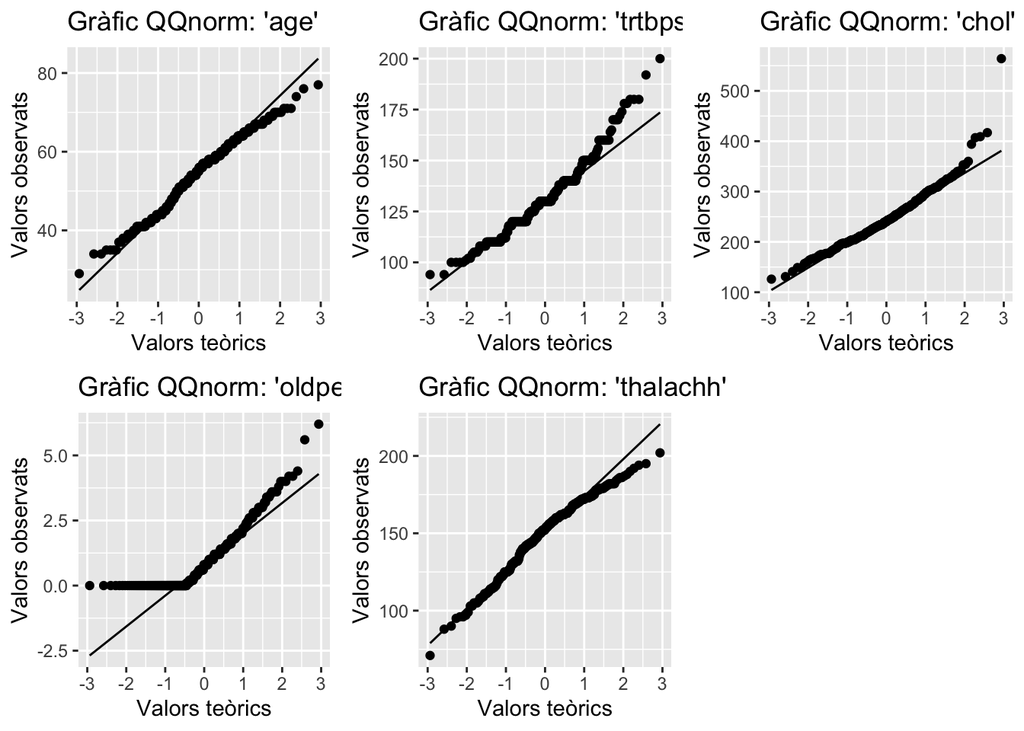

```r
# Creem els diferents gràfics QQ per comprovar si les dades de les variables segueixen o s'aproximen a una distribució normal:
qqAge <- ggplot(data = dfHeartAttack, aes(sample = age)) +
  geom_qq() +
  geom_qq_line() +
  labs(x = "Valors teòrics", y = "Valors observats") +
  ggtitle("Gràfic QQnorm: 'age'")

qqTRTBPS <- ggplot(data = dfHeartAttack, aes(sample = trtbps)) +
  geom_qq() +
  geom_qq_line() +
  labs(x = "Valors teòrics", y = "Valors observats") +
  ggtitle("Gràfic QQnorm: 'trtbps'")

qqChol <- ggplot(data = dfHeartAttack, aes(sample = chol)) +
  geom_qq() +
  geom_qq_line() +
  labs(x = "Valors teòrics", y = "Valors observats") +
  ggtitle("Gràfic QQnorm: 'chol'")

qqOldpeak <- ggplot(data = dfHeartAttack, aes(sample = oldpeak)) +
  geom_qq() +
  geom_qq_line() +
  labs(x = "Valors teòrics", y = "Valors observats") +
  ggtitle("Gràfic QQnorm: 'oldpeak'")

qqThalachh <- ggplot(data = dfHeartAttack, aes(sample = thalachh)) +
  geom_qq() +
  geom_qq_line() +
  labs(x = "Valors teòrics", y = "Valors observats") +
  ggtitle("Gràfic QQnorm: 'thalachh'")

# Mostrem els diferents gràfics de forma agrupada:
grid.newpage()
grid.arrange(qqAge, qqTRTBPS, qqChol, qqOldpeak, qqThalachh, ncol=3)
```

Amb els resultats obtinguts, podem observar que les variables numèriques, tot i no tenir un a distribució normal, sí semblen tendir a aquesta. L’únic cas que podriem considerar que no és tant així seria per la variable *oldpeak*, ja que és la única que no té una distribució tant propera a la línia que podriem considerar que defineix la normalitat.

## 4.2 Correlació de les variables

Tot i que ja s’ha vist anteriorment que semblava que no hi havia xorrelacions molt fortes entre les diferents variables, procedim a analitzar-ho més a fons:

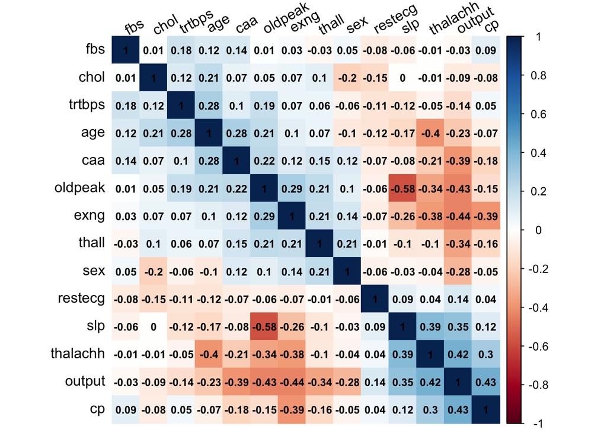

```r
# Generam un gràfic de correlació que ens permeti analitzar-ho fàcilment (només aquelles variables que no siguin factors):
if (!require('corrplot')) install.packages('corrplot'); library("corrplot")
res<-cor(dfHeartAttack[, 1:14])
corrplot(res, method="color", tl.col="black", tl.srt=30, order = "AOE", number.cex=0.75, sig.level = 0.01, addCoef.col = "black")
```

Es confirma que no hi ha correlacions molt fortes entre ninguna de les variables que conformen el joc de dades. No obstant, existeixen algunes correlacions moderades, tant positives com negatives.

La més forta d’aquestes correspon amb una correlació negativa entre el patró de canvi de l’electrocardiograma en una situació d’estrés (variable *slp*) i el canvi en el segment ST de l’electrocardiograma (variable *oldpeak*). Mentre que la més forta amb valor positiu correspon a ula correlació entre el tipus de dolor toràcic (variable *cp*) i la probabilitat d’un atac de cor (variable *output*).

Cal tenir en compte que aquestes correlacions no són molt fortes i el signe ens indica que quan una augmenta o disminueix, la variable correlacionada actúa de la mateixa manera en certa proporció segons la potència d’aquesta correlació.

Amb els resultats obtinguts, no hi ha cap evidència que, per les correlacions existents, es pugui disminuïr el nombre de variables.

# 5 Representació dels resultats a partir de taules i gràfiques

# 6 Resolució del problema